# Integración de inteligencia artificial en la enseñanza de programación en R y análisis de datos en el nivel universitario

Módulo 2: Entornos de Desarrollo Local y Asistentes de Código

Dra Teresa Boca

## Módulo 2: Entornos de Desarrollo Local y Asistentes de Código

[figure not shown]

## Temario

**Visual Studio Code (VS Code):**

- Instalación local y configuración del sistema operativo.
- Integración con GitHub Copilot y configuración de extensiones de R.
- Funcionalidades avanzadas: Uso del chat para generar archivos desde cero, mejorar código existente.
- Integración con Github y Posit Conec Cloud

## Instalación de R

[figure not shown]

- **R**: se descarga desde el [CRAN](https://cran.r-project.org/index.html)(*Comprehensive R Archive Network*).
- actualizaciones frecuentes (cada ~3 meses).
- La instalación básica de R (*core*) trae paquetes base: `base`, `graphics`, `stats`, `utils`

## Buscar en google de GitHub Copilot

Crear cuenta de GitHub Copilot

[figure not shown]

## Crear un usuario gratuito paso 1

[figure not shown]

## Crear cuenta gratuita paso 2

[figure not shown]

## Verificar la creación gratuita de la cuenta

[figure not shown]

## Instalar Visual Studio Code (gratis y local)

[figure not shown]

[figure not shown]

## Ejemplo práctico

Vamos a crear una carpeta con una base de datos a analizar en nuestro caso, serán datos obtenidos de [estimaciones agrícolas](https://datosestimaciones.magyp.gob.ar/).

[figure not shown]

## Ejemplo práctico

Vamos a analizar la base de datos Rendimientos_decada.xlsx

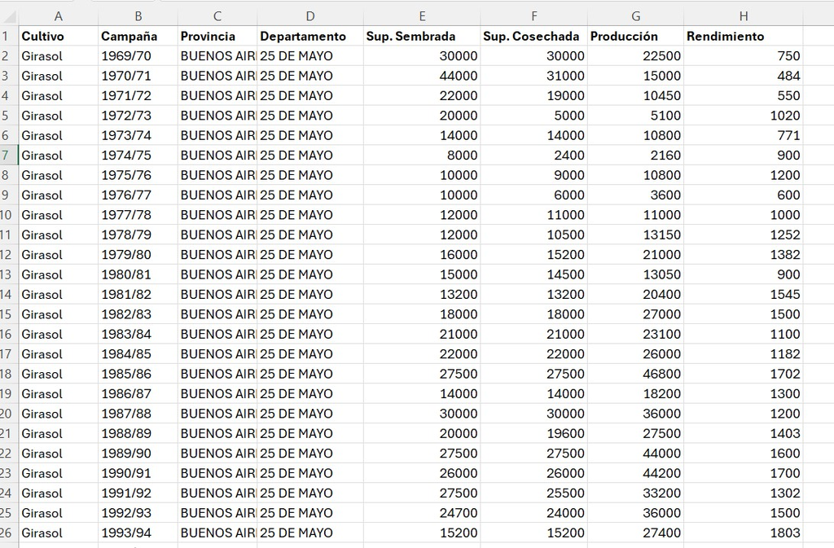

## Ejemplo práctico

Prompt a utilizar:

*Generar un archivo `descriptiva.qmd` reproducible que: Lea `Rendimiento.xlsx` y verifique los nombres de las variables. Muestre una breve descripción de los datos.*

*Realice **estadística descriptiva** de las variables numéricas. Genere una **tabla descriptiva agrupada por cultivo**.*

*Incluya algunos gráficos descriptivos.*

*Utilice código claro y sencillo Renderizar el archivo*

## Ejemplo práctico (continuación)

Ahora vamos a pedir que cree una Shiny app

Prompt a utilizar:

*Creá una aplicación Shiny que: Lea `Rendimiento.xlsx`.*

*Muestre la relación entre Sup. Sembrada y Sup. Cosechada por Campaña en el mismo gráfico.*

*Tenga un filtro dinámico para seleccionar el cultivo.*

*Que maneje correctamente los valores faltantes.*

*Utilice código claro y sencillo Renderizar el archivo*

## App en Shiny

[figure not shown]

## Publicar en Posit Connect Cloud

Qué herramientas necesitás

| Herramienta | Para qué sirve (simple) |
| --- | --- |
| VS Code | Donde abrís y editás los archivos del proyecto |
| Git | Registra cambios en tu PC y permite subirlos a GitHub |
| GitHub | Donde guardás tu proyecto en internet |
| GitHub Copilot | Asistente dentro de VS Code para ayudarte a escribir/modificar |
| Posit Connect Cloud | Donde publicás la app para compartir un enlace |
| R | Lenguaje necesario para ejecutar Shiny |

## Cuentas y programas necesarios

- Crear cuenta en **GitHub**: https://github.com/signup
- Entrar a **Posit Connect Cloud** (recomendado: “Sign in with GitHub”):  
  https://connect.posit.cloud/
- Instalar **VS Code**: https://code.visualstudio.com/
- Instalar **Git**: https://git-scm.com/downloads
- Instalar **R**: https://cran.r-project.org/

## Crear un repositorio en Github

Entrar a Github con tu cuenta y crear un repositorio

[figure not shown]

## Conectar el proyecto actual al repositorio creado

Prompt recomendado

*En el repositorio existente de GitHub AI_R, de mi cuenta de GitHub: Conecta el proyecto actual con ese repositorio. Sube al repositorio la aplicación que estoy desarrollando. Incluye también el archivo de datos Rendimiento_decada.xlsx. Realiza un commit con los archivos agregados. Haz el push al repositorio de GitHub. Verifica que el repositorio AI_R contenga correctamente la aplicación y el archivo Rendimiento_decada.xlsx.*

*No crees un nuevo repositorio y no modifiques el código de la aplicación ni el archivo de datos.*

## Repositorio en Github

[figure not shown]

## Lógica de la conexión

[output not shown]

## Publicar en Posit Connect Cloud

Pasos simples:

- Entrar a https://connect.posit.cloud/
- Click en `Publish`
- Elegir repositorio de `GitHub`
- Confirmar publicación
- Compartir el enlace de la app

[figure not shown]

[app online](https://connect.posit.cloud/biometriatb/content/01a10832-66e0-617e-459b-57715818dd08)

## ¿Qué hace Git cuando la AI sube tu aplicación a GitHub?

**① `git add`** 📁 **AGREGAR** Selecciona los archivos que queremos subir. ↓

**② `git commit`** 💾 **GUARDAR** Guarda los cambios como una nueva versión del proyecto. ↓

**③ `git push`** ☁️ **SUBIR** Envía esa versión desde nuestra computadora a GitHub.

**AGREGAR → GUARDAR → SUBIR**

`git add` → `git commit` → `git push`